# R Notebook

Inlezen data

```r
Attrition = read.csv('IBM_HR_Attrition.csv')
```

Structuur data

```r
str(Attrition)
```

```
'data.frame':   1470 obs. of  35 variables:
 $ Age                     : int  41 49 37 33 27 32 59 30 38 36 ...
 $ Attrition               : Factor w/ 2 levels "No","Yes": 2 1 2 1 1 1 1 1 1 1 ...
 $ BusinessTravel          : Factor w/ 3 levels "Non-Travel","Travel_Frequently",..: 3 2 3 2 3 2 3 3 2 3 ...
 $ DailyRate               : int  1102 279 1373 1392 591 1005 1324 1358 216 1299 ...
 $ Department              : Factor w/ 3 levels "Human Resources",..: 3 2 2 2 2 2 2 2 2 2 ...
 $ DistanceFromHome        : int  1 8 2 3 2 2 3 24 23 27 ...
 $ Education               : int  2 1 2 4 1 2 3 1 3 3 ...
 $ EducationField          : Factor w/ 6 levels "Human Resources",..: 2 2 5 2 4 2 4 2 2 4 ...
 $ EmployeeCount           : int  1 1 1 1 1 1 1 1 1 1 ...
 $ EmployeeNumber          : int  1 2 4 5 7 8 10 11 12 13 ...
 $ EnvironmentSatisfaction : int  2 3 4 4 1 4 3 4 4 3 ...
 $ Gender                  : Factor w/ 2 levels "Female","Male": 1 2 2 1 2 2 1 2 2 2 ...
 $ HourlyRate              : int  94 61 92 56 40 79 81 67 44 94 ...
 $ JobInvolvement          : int  3 2 2 3 3 3 4 3 2 3 ...
```

[output cut: 21 more lines]

Wanneer we kijken in het bestand zelf valt al snel op dat er veel het percentage van mensen dat is gebleven hoger is dan het percentage dat is weggegaan. Als we dus het aantal mensen die zijn gebleven delen door het totaal komen we op 84% uit. Dit getal gebruiken we als baseline om te meten of het model beter of slechter werkt dan simpelweg voorspellen dat iedereen blijft.

```r
table(Attrition$Attrition)
```

```
  No  Yes
1233  237
```

```r
1233/1470
```

```
[1] 0.8387755
```

Attrition is nu een Factor, No/Yes. Omschrijven naar een Integer. 1 = Ja/Yes 0 = Nee/No Op basis van Alfabet de N van No komt eerder dan de Y van Yes.

```r
Attrition$Attrition = as.integer(Attrition$Attrition)
```

```r
Attrition$Attrition[Attrition$Attrition == 1] <- 0
Attrition$Attrition[Attrition$Attrition == 2] <- 1
```

Als eerst doen we een correlatie analyse om aan te tonen of er verbanden binnen de dataset gevonden kunnen worden.

```r
CorrelatieAn <- Attrition[, c("Attrition", "DistanceFromHome", "Education", "Age", "DailyRate", "EmployeeCount", "EmployeeNumber", "EnvironmentSatisfaction", "HourlyRate", "JobInvolvement", "JobLevel", "JobSatisfaction", "MonthlyIncome", "MonthlyRate", "NumCompaniesWorked", "PercentSalaryHike", "PerformanceRating", "StandardHours", "StockOptionLevel", "TotalWorkingYears", "TrainingTimesLastYear", "WorkLifeBalance", "YearsAtCompany", "YearsInCurrentRole", "YearsSinceLastPromotion", "YearsWithCurrManager" )]
```

```r
cor(CorrelatieAn)
```

```
the standard deviation is zero
```

```
                           Attrition DistanceFromHome
Attrition                1.000000000      0.077923583
DistanceFromHome         0.077923583      1.000000000
Education               -0.031372820      0.021041826
Age                     -0.159205007     -0.001686120
DailyRate               -0.056651992     -0.004985337
EmployeeCount                     NA               NA
EmployeeNumber          -0.010577243      0.032916407
EnvironmentSatisfaction -0.103368978     -0.016075327
HourlyRate              -0.006845550      0.031130586
JobInvolvement          -0.130015957      0.008783280
JobLevel                -0.169104751      0.005302731
JobSatisfaction         -0.103481126     -0.003668839
MonthlyIncome           -0.159839582     -0.017014445
MonthlyRate              0.015170213      0.027472864
NumCompaniesWorked       0.043493739     -0.029250804
PercentSalaryHike       -0.013478202      0.040235377
PerformanceRating        0.002888752      0.027109618
StandardHours                     NA               NA
StockOptionLevel        -0.137144919      0.044871999
TotalWorkingYears       -0.171063246      0.004628426
TrainingTimesLastYear   -0.059477799     -0.036942234
WorkLifeBalance         -0.063939047     -0.026556004
YearsAtCompany          -0.134392214      0.009507720
YearsInCurrentRole      -0.160545004      0.018844999
YearsSinceLastPromotion -0.033018775      0.010028836
YearsWithCurrManager    -0.156199316      0.014406048
                           Education          Age     DailyRate
Attrition               -0.031372820 -0.159205007 -0.0566519919
DistanceFromHome         0.021041826 -0.001686120 -0.0049853374
Education                1.000000000  0.208033731 -0.0168064332
Age                      0.208033731  1.000000000  0.0106609426
DailyRate               -0.016806433  0.010660943  1.0000000000
EmployeeCount                     NA           NA            NA
EmployeeNumber           0.042070093 -0.010145467 -0.0509904337
EnvironmentSatisfaction -0.027128313  0.010146428  0.0183548543
HourlyRate               0.016774829  0.024286543  0.0233814215
JobInvolvement           0.042437634  0.029819959  0.0461348740
JobLevel                 0.101588886  0.509604228  0.0029663349
JobSatisfaction         -0.011296117 -0.004891877  0.0305710078
```

[output cut: 323 more lines]

```
JobSatisfaction                 -0.027656214
MonthlyIncome                    0.344078883
MonthlyRate                     -0.036745905
NumCompaniesWorked              -0.110319155
PercentSalaryHike               -0.011985248
PerformanceRating                0.022827169
StandardHours                             NA
StockOptionLevel                 0.024698227
TotalWorkingYears                0.459188397
TrainingTimesLastYear           -0.004095526
WorkLifeBalance                  0.002759440
YearsAtCompany                   0.769212425
YearsInCurrentRole               0.714364762
YearsSinceLastPromotion          0.510223636
YearsWithCurrManager             1.000000000
```

Ook zien we een sterke correlatie van 0.77 tussen de PerformanceRating en de PercentSalaryHike. Het is dus ook te concluderen dat IBM haar werknemers opslag geeft op basis van hun prestaties.

Op basis van deze gegevens zouden we dus kunnen zeggen dat IBM een beloningsmodel heeft voor loyale (langer werkenden) hardwerkende (zet zich ook om in hogere beoordelingen) werknemers.

Ook zien we dat Attrition een aantal lage correlaties heeft over het hele bord. Het is daarom wellicht handig om dit verder te onderzoek doormiddel van een Logistieke Regressie Model. ALs het mogelijk is om een accuraat model hiermee te bouwen dan weten dat dit van grote invloed is.

Volgens smallbusiness.com is de definitie van attrition:

Attrition is the normal life cycle of employment. Employees who move, retire, pass away or leave the company to raise a family or attend school represent the usual ebb and flow of staffers through a business. In other words, when it comes to attrition, employees are leaving not because they have a problem with your company or their jobs – it’s a matter of life unfolding. Attrition tends to be higher in companies located in transient cities and in organizations that hire older employees as a matter of practice.

Op basis van deze informatie stellen we onze variabelen vast. We stellen dat de afhankelijke variabele Attrition is. De onafhankelijke variabelen die hiervan op invloed zijn:

DistanceFromHome: Een te lange reistijd kan ervoor dat er minder tijd is voor andere dingen in het leven van een werknemer waardoor een werknemer voor de keuze tussen verhuizen of ander werk zoeken komt te staan.

Inkomsten variabelen tellen we niet mee omdat dit van invloed is op een TurnoverRate en niet een AttritionRate.

Job Involvement laat zien hoeveel iemand bezig is met zijn of haar werk, dit kan op den duur een mismatch worden met het persoonlijke doel van een medewerker waardoor hij of zij besluit te vertrekken.

Work life balance gaat in op de balans tussen een werknemer zijn of haar leven en werk, dit kan dus veel effect hebben op het besluit om wel of niet te vertrekken.

Gender wordt ook meegeteld aangezien het wel bekend is dat mannen en vrouwen andere dingen uit het leven willen, dit kan dus bijdragen aan de beslissing om wel of niet te blijven.

MaritalStatus, wellicht heeft de invloed van een partner effect op de beslissing om wel of niet te blijven.

Total working years en Age, zoals de definitie al zegt zijn deze tijdsvariabelen van effect op je attrition, we moeten deze dus meenemen.

```r
str(Attrition)
```

```
'data.frame':   1470 obs. of  35 variables:
 $ Age                     : int  41 49 37 33 27 32 59 30 38 36 ...
 $ Attrition               : num  1 0 1 0 0 0 0 0 0 0 ...
 $ BusinessTravel          : Factor w/ 3 levels "Non-Travel","Travel_Frequently",..: 3 2 3 2 3 2 3 3 2 3 ...
 $ DailyRate               : int  1102 279 1373 1392 591 1005 1324 1358 216 1299 ...
 $ Department              : Factor w/ 3 levels "Human Resources",..: 3 2 2 2 2 2 2 2 2 2 ...
 $ DistanceFromHome        : int  1 8 2 3 2 2 3 24 23 27 ...
 $ Education               : int  2 1 2 4 1 2 3 1 3 3 ...
 $ EducationField          : Factor w/ 6 levels "Human Resources",..: 2 2 5 2 4 2 4 2 2 4 ...
 $ EmployeeCount           : int  1 1 1 1 1 1 1 1 1 1 ...
 $ EmployeeNumber          : int  1 2 4 5 7 8 10 11 12 13 ...
 $ EnvironmentSatisfaction : int  2 3 4 4 1 4 3 4 4 3 ...
 $ Gender                  : Factor w/ 2 levels "Female","Male": 1 2 2 1 2 2 1 2 2 2 ...
 $ HourlyRate              : int  94 61 92 56 40 79 81 67 44 94 ...
 $ JobInvolvement          : int  3 2 2 3 3 3 4 3 2 3 ...
```

[output cut: 21 more lines]

```r
install.packages("caTools")
```

```
Error in install.packages : Updating loaded packages
```

```r
library(caTools)
```

```r
library(caTools)
```

we splitten met een ratio van 0.75 zodat er in 1 set 75% van de observaties zitten en 25% in de andere set.

```r
set.seed(214)
split = sample.split(Attrition$Attrition, SplitRatio = 0.75)
split
```

```
   [1]  TRUE FALSE FALSE  TRUE  TRUE FALSE  TRUE  TRUE  TRUE FALSE  TRUE  TRUE  TRUE FALSE  TRUE
  [16]  TRUE  TRUE FALSE  TRUE  TRUE  TRUE  TRUE  TRUE  TRUE FALSE  TRUE  TRUE  TRUE  TRUE  TRUE
  [31]  TRUE  TRUE FALSE FALSE  TRUE  TRUE  TRUE FALSE  TRUE  TRUE  TRUE FALSE  TRUE  TRUE  TRUE
  [46]  TRUE  TRUE  TRUE  TRUE  TRUE  TRUE FALSE  TRUE FALSE  TRUE  TRUE  TRUE FALSE FALSE  TRUE
  [61] FALSE  TRUE  TRUE  TRUE  TRUE  TRUE  TRUE  TRUE  TRUE  TRUE  TRUE  TRUE FALSE  TRUE  TRUE
  [76]  TRUE  TRUE FALSE  TRUE FALSE  TRUE  TRUE  TRUE  TRUE  TRUE  TRUE FALSE  TRUE  TRUE  TRUE
  [91]  TRUE  TRUE FALSE  TRUE  TRUE  TRUE  TRUE  TRUE  TRUE  TRUE  TRUE  TRUE  TRUE  TRUE FALSE
 [106]  TRUE  TRUE  TRUE  TRUE FALSE  TRUE FALSE  TRUE  TRUE  TRUE  TRUE  TRUE  TRUE  TRUE  TRUE
 [121]  TRUE  TRUE  TRUE  TRUE  TRUE  TRUE  TRUE  TRUE FALSE  TRUE FALSE  TRUE FALSE  TRUE  TRUE
 [136]  TRUE  TRUE  TRUE  TRUE  TRUE  TRUE FALSE  TRUE FALSE  TRUE FALSE  TRUE  TRUE  TRUE  TRUE
 [151]  TRUE  TRUE  TRUE  TRUE FALSE FALSE  TRUE  TRUE  TRUE  TRUE  TRUE  TRUE  TRUE  TRUE  TRUE
 [166]  TRUE  TRUE FALSE  TRUE  TRUE  TRUE  TRUE FALSE  TRUE FALSE  TRUE  TRUE  TRUE  TRUE  TRUE
 [181]  TRUE  TRUE  TRUE  TRUE  TRUE FALSE  TRUE FALSE  TRUE  TRUE  TRUE  TRUE FALSE  TRUE  TRUE
 [196]  TRUE FALSE  TRUE  TRUE  TRUE  TRUE  TRUE FALSE  TRUE  TRUE  TRUE  TRUE FALSE  TRUE  TRUE
 [211]  TRUE  TRUE FALSE  TRUE  TRUE  TRUE  TRUE  TRUE  TRUE  TRUE  TRUE  TRUE  TRUE  TRUE FALSE
```

[output cut: 53 more lines]

Nu zijn er 2 waardes toegekend: TRUE en FALSE, op basis van deze waardes zetten we ze nu in een set.

```r
attritionTrain = subset(Attrition, split == TRUE)
attritionTest = subset(Attrition, split == FALSE)

nrow(attritionTrain)
```

```
[1] 1103
```

```r
nrow(attritionTest)
```

```
[1] 367
```

Met de NROW functie controleren op de overeenkomt met de 75% 25% regel die we hierboven hebben beschreven.

Nu bouwen we het model.

```r
attritionLog = glm(Attrition ~ DistanceFromHome + JobInvolvement + WorkLifeBalance + Gender + MaritalStatus + TotalWorkingYears + Age, data=attritionTrain, family = binomial)

summary(attritionLog)
```

```
Call:
glm(formula = Attrition ~ DistanceFromHome + JobInvolvement +
    WorkLifeBalance + Gender + MaritalStatus + TotalWorkingYears +
    Age, family = binomial, data = attritionTrain)

Deviance Residuals:
    Min       1Q   Median       3Q      Max
-1.4084  -0.6130  -0.4579  -0.2846   2.8676

Coefficients:
                     Estimate Std. Error z value Pr(>|z|)
(Intercept)           0.63187    0.63048   1.002 0.316245
DistanceFromHome      0.02513    0.01009   2.492 0.012712 *
JobInvolvement       -0.45985    0.11790  -3.900 9.61e-05 ***
WorkLifeBalance      -0.30426    0.11989  -2.538 0.011157 *
GenderMale            0.18269    0.17844   1.024 0.305924
MaritalStatusMarried  0.23494    0.26087   0.901 0.367783
MaritalStatusSingle   1.12538    0.25754   4.370 1.24e-05 ***
TotalWorkingYears    -0.07051    0.01815  -3.884 0.000103 ***
Age                  -0.01228    0.01290  -0.952 0.340989
---
Signif. codes:  0 ‘***’ 0.001 ‘**’ 0.01 ‘*’ 0.05 ‘.’ 0.1 ‘ ’ 1

(Dispersion parameter for binomial family taken to be 1)

    Null deviance: 974.94  on 1102  degrees of freedom
Residual deviance: 868.11  on 1094  degrees of freedom
AIC: 886.11

Number of Fisher Scoring iterations: 5
```

Hier maken we voorspellingen op de trainingset.

```r
predictTrain = predict(attritionLog, type="response")

summary(predictTrain)
```

```
    Min.  1st Qu.   Median     Mean  3rd Qu.     Max.
0.006194 0.074310 0.128154 0.161378 0.216397 0.752155
```

```r
tapply(predictTrain, attritionTrain$Attrition, mean)
```

```
        0         1
0.1435333 0.2541108
```

We gaan nu een threshold zoeken om tegen te meten.

```r
install.packages("ROCR")
```

```
Error in install.packages : Updating loaded packages
```

```r
library(ROCR)
```

```r
ROCRpred = prediction(predictTrain, attritionTrain$Attrition)
```

```r
ROCRperf = performance(ROCRpred, "tpr", "fpr")
```

Nu gaan we het plotten (tekenen).

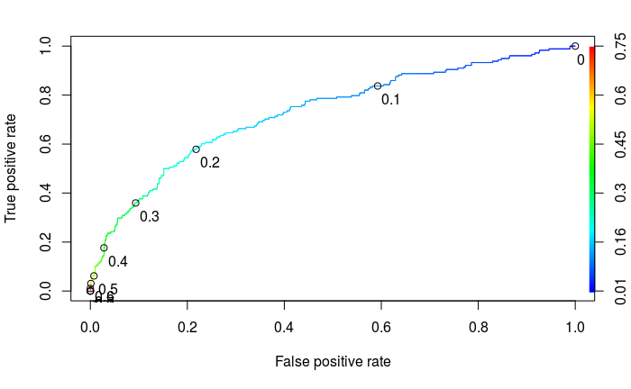

```r
plot(ROCRperf, colorize=TRUE, print.cutoffs.at=seq(0, 1, by=0.1),text.adj=c(-0.2, 1.7))
```

Op basis hiervan pakken we een threshold van 0.2 omdat we hierbij 60 procent goed voorspellen, tegen een FP van 0.21.

```r
predictTest = predict(attritionLog, type = "response", newdata = attritionTest)

table(attritionTest$Attrition, predictTest >= 0.2)
```

```
    FALSE TRUE
  0   228   80
  1    27   32
```

```r
(228+32)/367
```

```
[1] 0.7084469
```

71 procent. Dit model is dus niet nauwkeuriger dan de baseline en daarom valt het niet aan te raden om te gebruiken.